# activities from Hadley Wickham R for Data Science (2e)

```r
library(ggplot2)
library(tidyverse)
library(palmerpenguins)
library(ggthemes)
```

Section 1: Whole game Chapter 1: Data Visualization

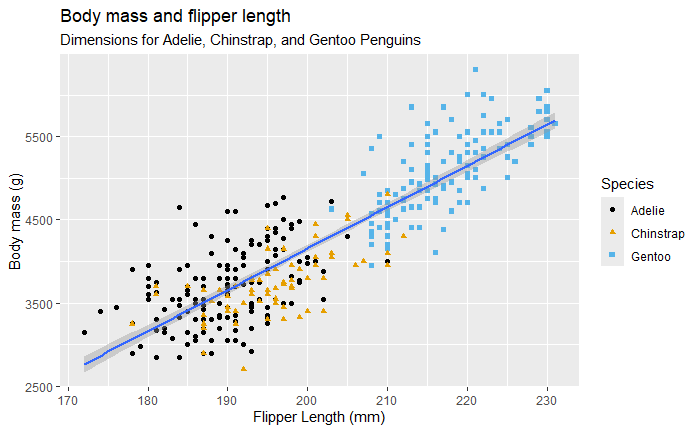

```r
ggplot(
  data=penguins,
  mapping = aes(x = flipper_length_mm, y=body_mass_g)
  ) +
  geom_point(mapping = aes(color = species, shape = species)) +
  geom_smooth(method ="lm") +
  labs(
    title = "Body mass and flipper length",
    subtitle = "Dimensions for Adelie, Chinstrap, and Gentoo Penguins",
    x = "Flipper Length (mm)", y="Body mass (g)",
    color = "Species", shape = "Species"
    ) +
  scale_color_colorblind()
```

1.2.5 Exercises

Make a scatterplot of bill_depth_mm vs. bill_length_mm. That is, make a scatterplot with bill_depth_mm on the y-axis and bill_length_mm on the x-axis. Describe the relationship between these two variables.

Add the following caption to the plot you made in the previous exercise: “Data come from the palmerpenguins package.” Hint: Take a look at the documentation for labs().

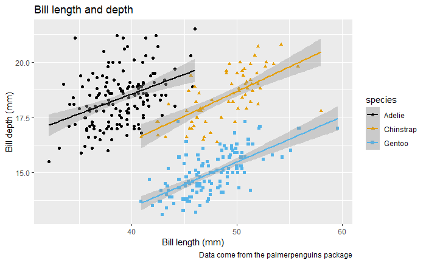

```r
ggplot(
  data=penguins,
  mapping = aes(y=bill_depth_mm, x=bill_length_mm, color = species, shape = species)
       ) +
  geom_point() +
  geom_smooth(method="lm") +
  labs(
    title = "Bill length and depth",
    y="Bill depth (mm)", x="Bill length (mm)",
    caption = "Data come from the palmerpenguins package"
  ) +
  scale_color_colorblind()
```

What happens if you make a scatterplot of species vs. bill_depth_mm? What might be a better choice of geom?

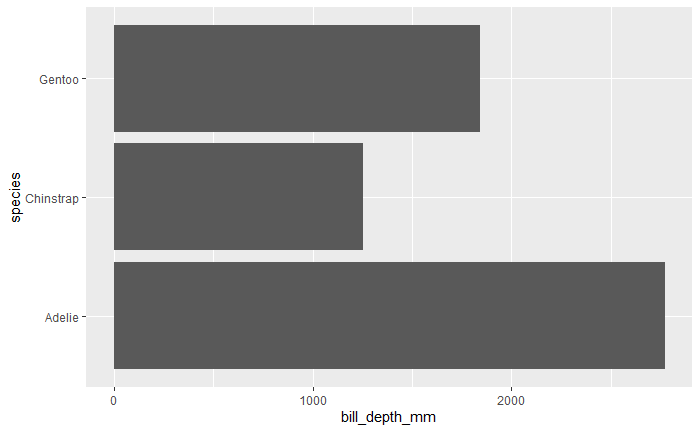

```r
ggplot(
  data=penguins,
  mapping =aes(x=bill_depth_mm, y=species
               )
  ) +
  geom_col()
```

Why does the following give an error and how would you fix it?

ggplot(data = penguins) + geom_point()

Need to name x and y variables - trying to plot without any data!

```
Warning: Removed 2 rows containing missing values or values outside the scale range (`geom_point()`).
```

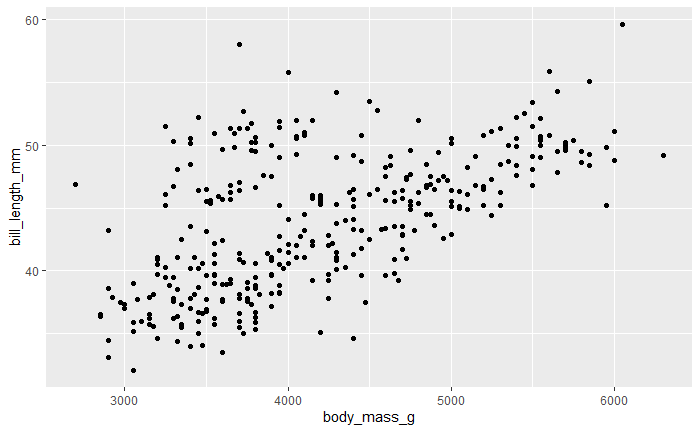

```r
ggplot(data = penguins,
       mapping=aes(x=body_mass_g, y=bill_length_mm)
       ) +
  geom_point()
```

What does the na.rm argument do in geom_point()? What is the default value of the argument? Create a scatterplot where you successfully use this argument set to TRUE.

na.rm = If FALSE, the default, missing values are removed with a warning. If TRUE, missing values are silently removed.

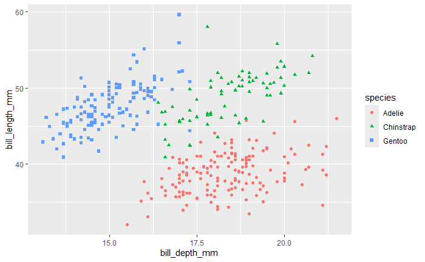

```r
ggplot(
  data=penguins,
  mapping=aes(x=bill_depth_mm, y =bill_length_mm, color=species, shape=species)
  ) +
  geom_point(na.rm=TRUE)
```

```r
NA
NA
```

Recreate the following visualization. What aesthetic should bill_depth_mm be mapped to? And should it be mapped at the global level or at the geom level?

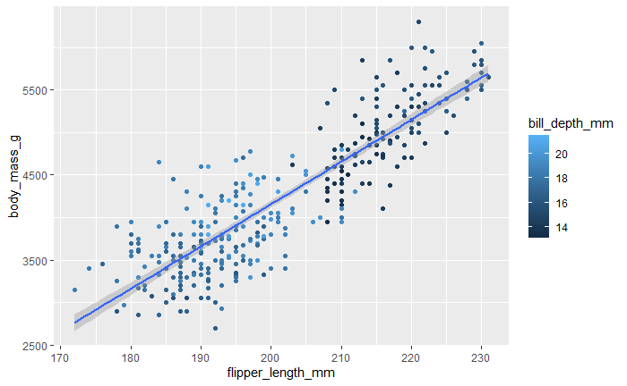

```r
ggplot(
  data=penguins,
  mapping=aes(x=flipper_length_mm, y=body_mass_g)
  ) +
geom_point(
  mapping = aes(color=bill_depth_mm)
) +
geom_smooth(

  method="lm")
```

Run this code in your head and predict what the output will look like. Then, run the code in R and check your predictions.

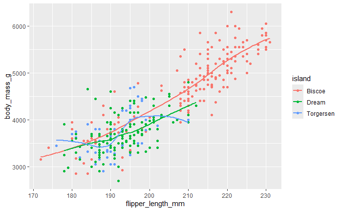

```r
ggplot(
  data = penguins,
  mapping = aes(x = flipper_length_mm, y = body_mass_g, color = island)
) +
  geom_point() +
  geom_smooth(se = FALSE)
```

Will these two graphs look different? Why/why not?

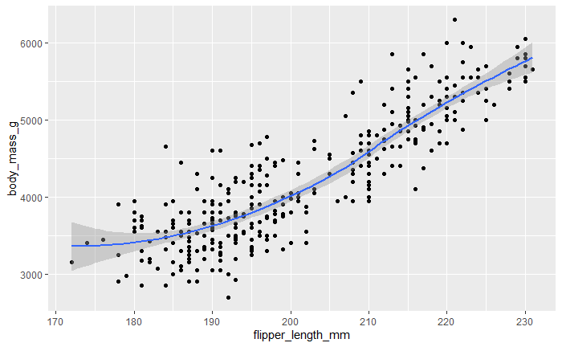

```r
ggplot(
  data = penguins,
  mapping = aes(x = flipper_length_mm, y = body_mass_g)
) +
  geom_point() +
  geom_smooth()
```

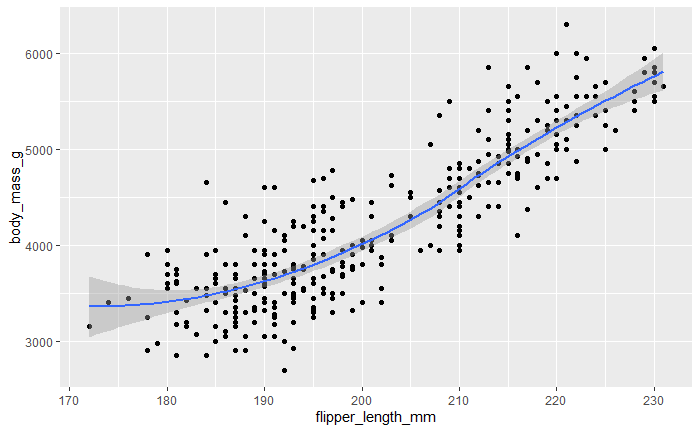

```r
ggplot() +
  geom_point(
    data = penguins,
    mapping = aes(x = flipper_length_mm, y = body_mass_g)
  ) +
  geom_smooth(
    data = penguins,
    mapping = aes(x = flipper_length_mm, y = body_mass_g)
  )
```

1.3 ggplot2 calls

As we move on from these introductory sections, we’ll transition to a more concise expression of ggplot2 code. So far we’ve been very explicit, which is helpful when you are learning:

ggplot( data = penguins, mapping = aes(x = flipper_length_mm, y = body_mass_g) ) + geom_point()

Typically, the first one or two arguments to a function are so important that you should know them by heart. The first two arguments to ggplot() are data and mapping, in the remainder of the book, we won’t supply those names. That saves typing, and, by reducing the amount of extra text, makes it easier to see what’s different between plots. That’s a really important programming concern that we’ll come back to in Chapter 25.

Rewriting the previous plot more concisely yields:

ggplot(penguins, aes(x = flipper_length_mm, y = body_mass_g)) + geom_point()

In the future, you’ll also learn about the pipe, |>, which will allow you to create that plot with:

penguins |> ggplot(aes(x = flipper_length_mm, y = body_mass_g)) + geom_point()

1.4 Visualizing distributions

1.4.1 A categorical variable

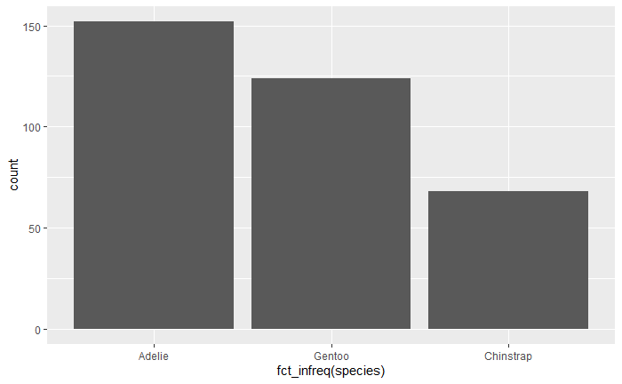

```r
ggplot(penguins, aes(x = fct_infreq(species))) +
  geom_bar()
```

1.4.2 A numerical variable

A variable is numerical (or quantitative) if it can take on a wide range of numerical values, and it is sensible to add, subtract, or take averages with those values. Numerical variables can be continuous or discrete.

One commonly used visualization for distributions of continuous variables is a histogram.

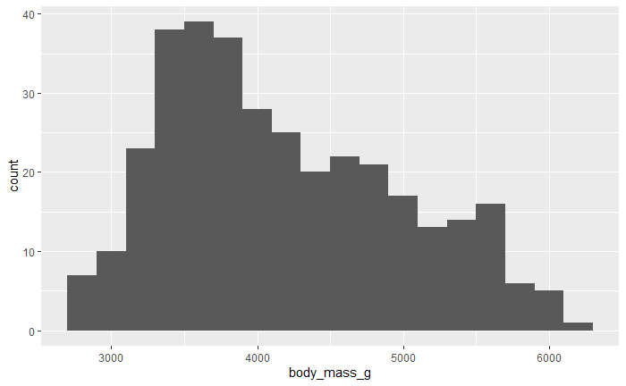

```r
ggplot(penguins, aes(x=body_mass_g))+
  geom_histogram(binwidth = 200)
```

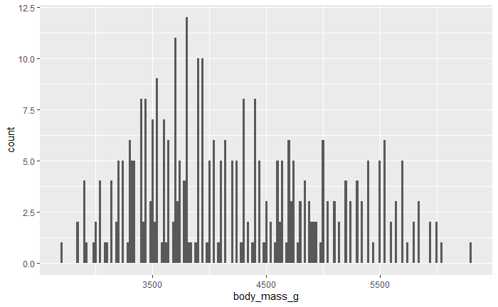

```r
ggplot(penguins, aes(x=body_mass_g))+
  geom_histogram(binwidth = 20)
```

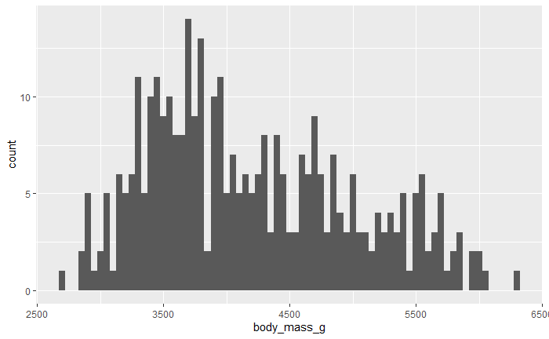

```r
ggplot(penguins, aes(x=body_mass_g))+
  geom_histogram(binwidth = 50)
```

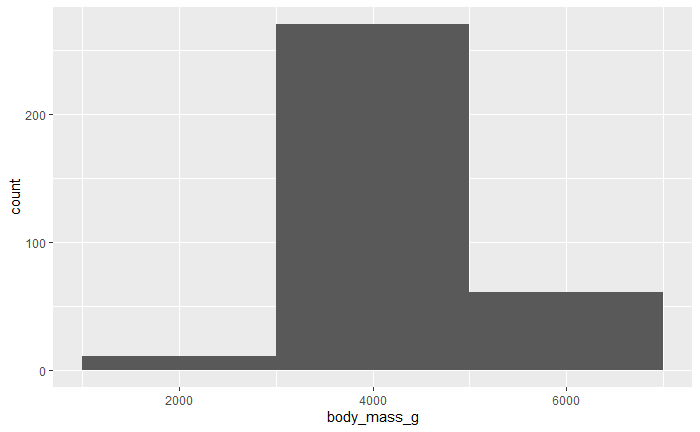

```r
ggplot(penguins, aes(x=body_mass_g))+
  geom_histogram(binwidth = 2000)
```

An alternative visualization for distributions of numerical variables is a density plot. A density plot is a smoothed-out version of a histogram and a practical alternative, particularly for continuous data that comes from an underlying smooth distribution. We won’t go into how geom_density() estimates the density (you can read more about that in the function documentation), but let’s explain how the density curve is drawn with an analogy. Imagine a histogram made out of wooden blocks. Then, imagine that you drop a cooked spaghetti string over it. The shape the spaghetti will take draped over blocks can be thought of as the shape of the density curve. It shows fewer details than a histogram but can make it easier to quickly glean the shape of the distribution, particularly with respect to modes and skewness.

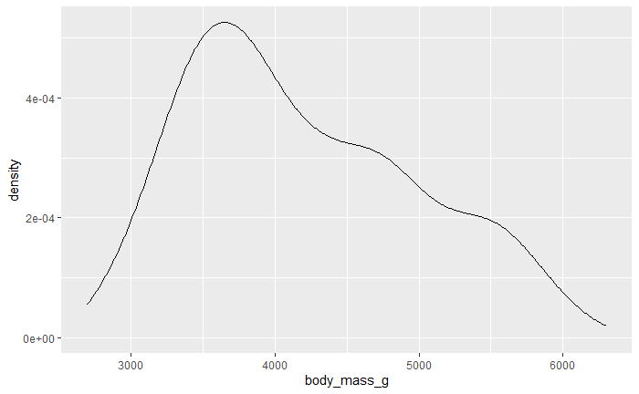

```r
ggplot(penguins, aes(x=body_mass_g))+
  geom_density()
```

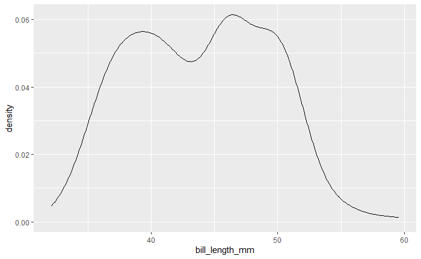

```r
ggplot(penguins, aes(x=bill_length_mm))+
  geom_density()
```

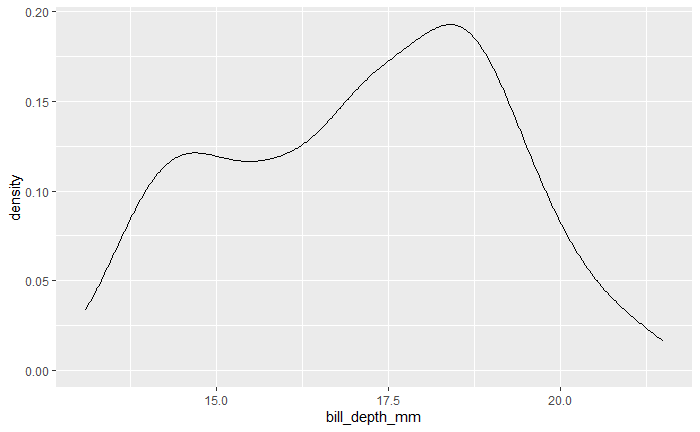

```r
ggplot(penguins, aes(x=bill_depth_mm))+
  geom_density()
```

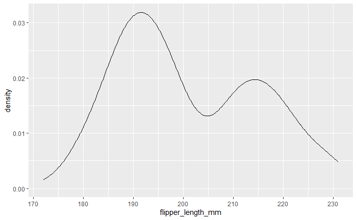

```r
ggplot(penguins, aes(x=flipper_length_mm))+
  geom_density()
```

1.4.3 Exercises

Make a bar plot of species of penguins, where you assign species to the y aesthetic. How is this plot different?

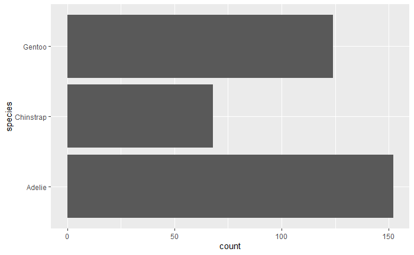

```r
ggplot(penguins,aes(y=species))+
  geom_bar(
  )
```

How are the following two plots different? Which aesthetic, color or fill, is more useful for changing the color of bars?

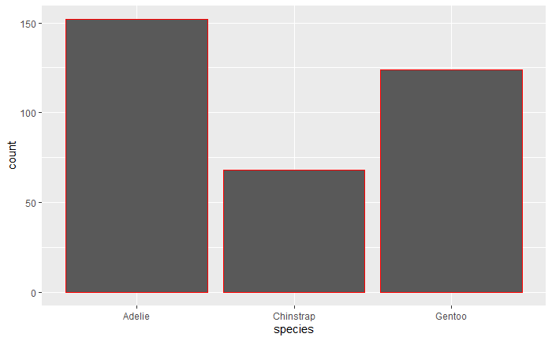

```r
ggplot(penguins, aes(x = species)) +
  geom_bar(color = "red")
```

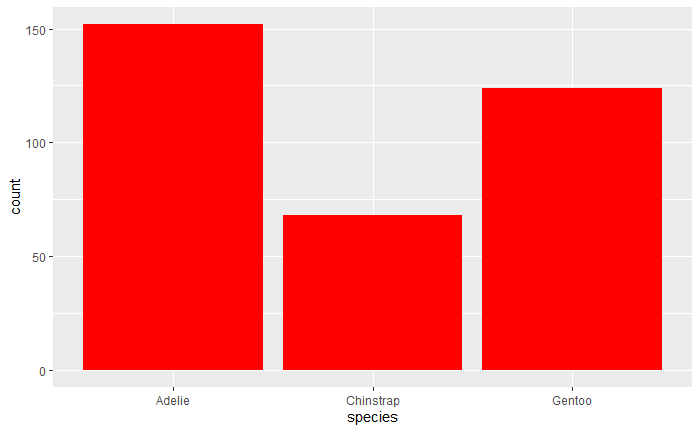

```r
ggplot(penguins, aes(x = species)) +
  geom_bar(fill = "red")
```

What does the bins argument in geom_histogram() do? –determine the number of bins (overridden by binwidth)

Make a histogram of the carat variable in the diamonds dataset that is available when you load the tidyverse package. Experiment with different binwidths. What binwidth reveals the most interesting patterns?

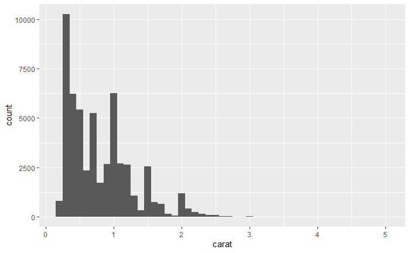

```r
ggplot(diamonds,aes(x=carat))+
  geom_histogram(binwidth=.1)
```

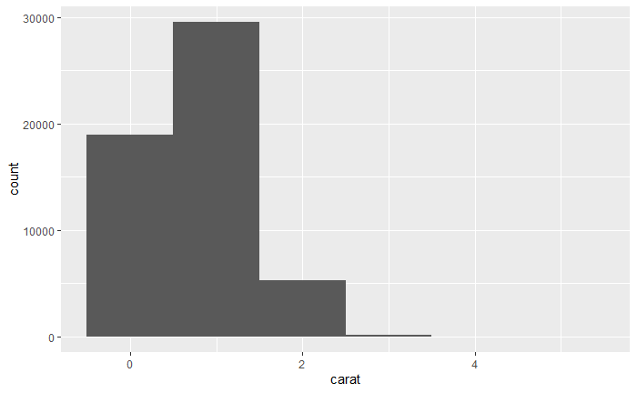

```r
ggplot(diamonds,aes(x=carat))+
  geom_histogram(binwidth=1)
```

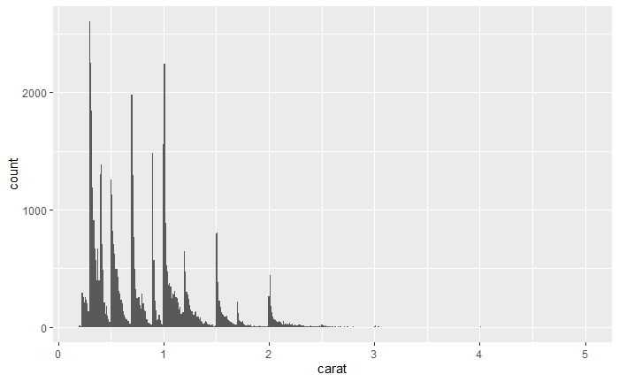

```r
ggplot(diamonds,aes(x=carat))+
  geom_histogram(binwidth=.01)
```

```r
NA
NA
```

1.5 Visualizing relationships

To visualize a relationship we need to have at least two variables mapped to aesthetics of a plot. In the following sections you will learn about commonly used plots for visualizing relationships between two or more variables and the geoms used for creating them.

1.5.1 A numerical and a categorical variable

[output not shown]

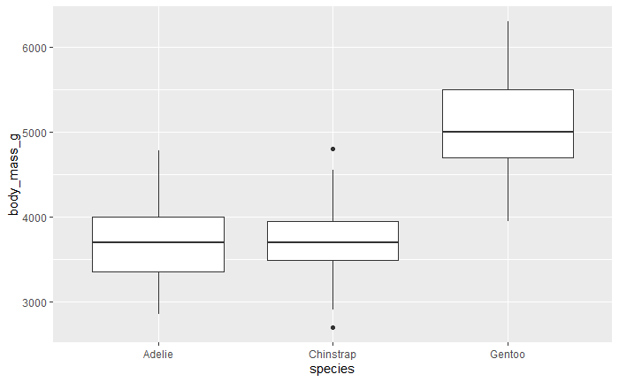

```r
ggplot(penguins, aes(x=species, y=body_mass_g))+
  geom_boxplot()
```

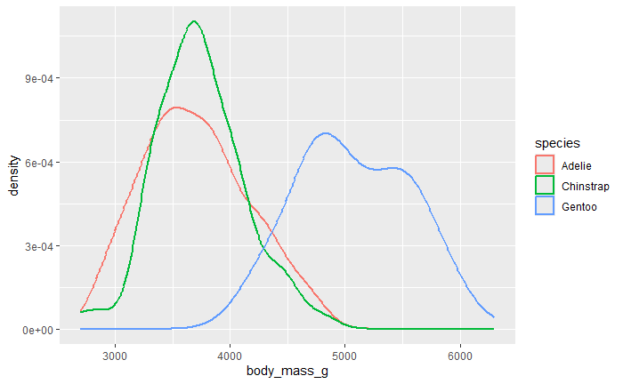

```r
ggplot(penguins,aes(x=body_mass_g, color=species))+
  geom_density(linewidth=0.75)
```

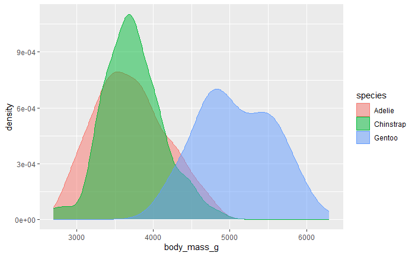

```r
ggplot(penguins,aes(x=body_mass_g, color=species, fill=species))+
  geom_density(alpha=0.5)
```

Note the terminology we have used here:

```
We map variables to aesthetics if we want the visual attribute represented by that aesthetic to vary based on the values of that variable.
Otherwise, we set the value of an aesthetic.
```

1.5.2 Two categorical variables

We can use stacked bar plots to visualize the relationship between two categorical variables. For example, the following two stacked bar plots both display the relationship between island and species, or specifically, visualizing the distribution of species within each island.

The first plot shows the frequencies of each species of penguins on each island. The plot of frequencies shows that there are equal numbers of Adelies on each island. But we don’t have a good sense of the percentage balance within each island.

The second plot, a relative frequency plot created by setting position = “fill” in the geom, is more useful for comparing species distributions across islands since it’s not affected by the unequal numbers of penguins across the islands. Using this plot we can see that Gentoo penguins all live on Biscoe island and make up roughly 75% of the penguins on that island, Chinstrap all live on Dream island and make up roughly 50% of the penguins on that island, and Adelie live on all three islands and make up all of the penguins on Torgersen.

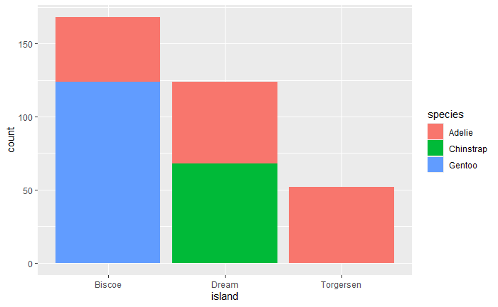

```r
ggplot(penguins, aes(x = island, fill = species)) +
  geom_bar()
```

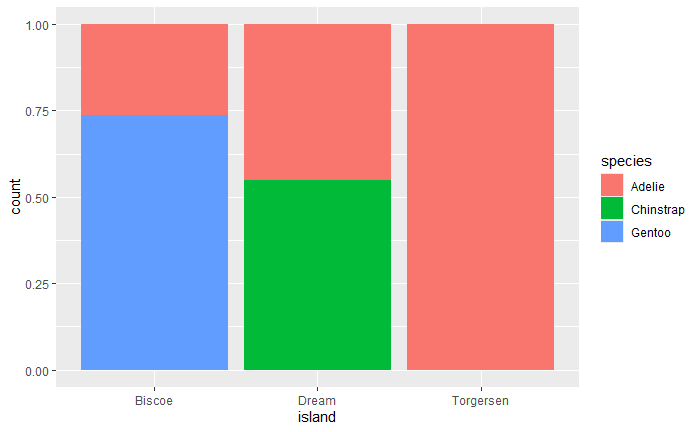

```r
ggplot(penguins, aes(x = island, fill = species)) +
  geom_bar(position = "fill")
```

1.5.3 Two numerical variables

So far you’ve learned about scatterplots (created with geom_point()) and smooth curves (created with geom_smooth()) for visualizing the relationship between two numerical variables. A scatterplot is probably the most commonly used plot for visualizing the relationship between two numerical variables.

1.5.4 Three or more variables

As we saw in Section 1.2.4, we can incorporate more variables into a plot by mapping them to additional aesthetics. For example, in the following scatterplot the colors of points represent species and the shapes of points represent islands.

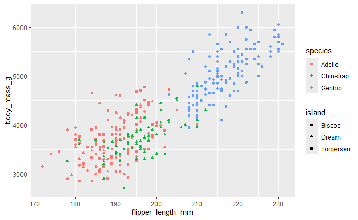

```r
ggplot(penguins, aes(x = flipper_length_mm, y = body_mass_g)) +
  geom_point(aes(color = species, shape = island))
```

However adding too many aesthetic mappings to a plot makes it cluttered and difficult to make sense of. Another way, which is particularly useful for categorical variables, is to split your plot into facets, subplots that each display one subset of the data.

To facet your plot by a single variable, use facet_wrap(). The first argument of facet_wrap() is a formula3, which you create with ~ followed by a variable name. The variable that you pass to facet_wrap() should be categorical.

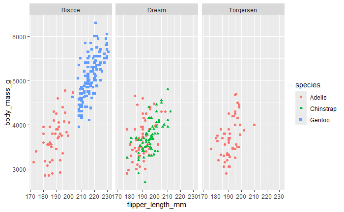

```r
ggplot(penguins, aes(x = flipper_length_mm, y = body_mass_g)) +
  geom_point(aes(color = species, shape = species)) +
  facet_wrap(~island)
```

1.5.5 Exercises

The mpg data frame that is bundled with the ggplot2 package contains 234 observations collected by the US Environmental Protection Agency on 38 car models. Which variables in mpg are categorical? Which variables are numerical? (Hint: Type ?mpg to read the documentation for the dataset.) How can you see this information when you run mpg?

Make a scatterplot of hwy vs. displ using the mpg data frame. Next, map a third, numerical variable to color, then size, then both color and size, then shape. How do these aesthetics behave differently for categorical vs. numerical variables?

In the scatterplot of hwy vs. displ, what happens if you map a third variable to linewidth?

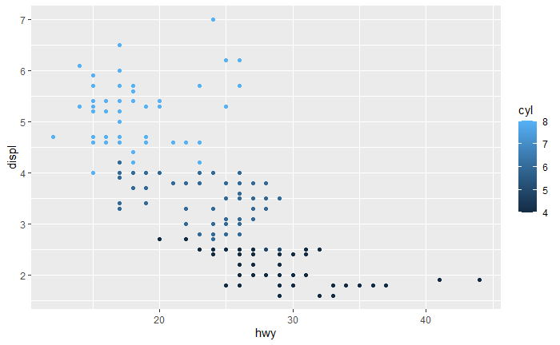

```r
ggplot(mpg, aes(x=hwy, y=displ, color=cyl))+
  geom_point()
```

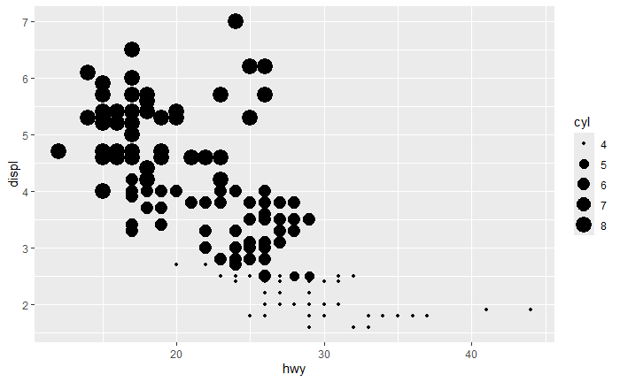

```r
ggplot(mpg, aes(x=hwy, y=displ, size=cyl))+
  geom_point()
```

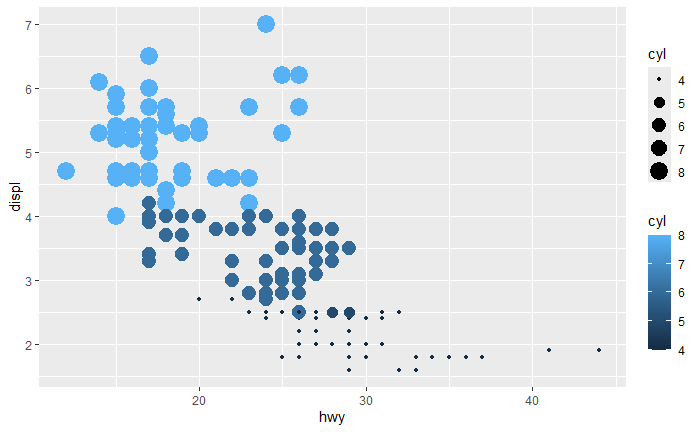

```r
ggplot(mpg, aes(x=hwy, y=displ, color=cyl, size=cyl))+
  geom_point()
```

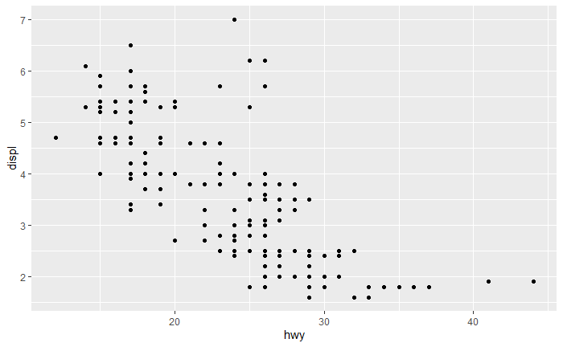

```r
ggplot(mpg, aes(x=hwy, y=displ, linewidth=class))+
  geom_point()
```

What happens if you map the same variable to multiple aesthetics?

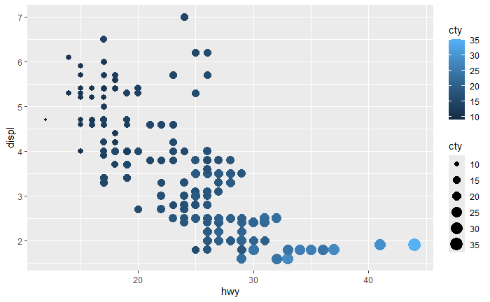

```r
ggplot(mpg, aes(x=hwy, y=displ, color=cty, size=cty))+
  geom_point()
```

Make a scatterplot of bill_depth_mm vs. bill_length_mm and color the points by species. What does adding coloring by species reveal about the relationship between these two variables? What about faceting by species?

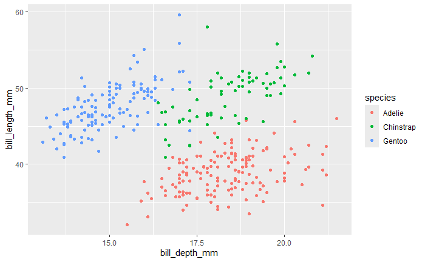

```r
ggplot(penguins,aes(x=bill_depth_mm, y=bill_length_mm, color=species))+
  geom_point()
```